# Assotiation Rules

Laura Julià

November 23, 2018

# 1. Importació de la base de dades

```r
dd <- read.table("Booking_data_preprocessada.csv",header=T, sep=",");

dcat<-dd[,sapply(dd, is.factor)] # Selecció de les variables categòriques

dtrans<-as(dcat, "transactions")# Transformación a transacciones
```

# 2. Itemsets més freqüents

```r
foo<-function(x){length(levels(x))}
sum(sapply(dcat, foo)) # suma de les categories que hi ha en tots els factors de la base de dades.
```

```
## [1] 2018
```

En total hi ha 2018 nivells diferents entre les 12 variables categòriques que tenim a la bbdd.

I més concretament, en cada variable hi ha el següent nombre de nivells:

```r
library(knitr)
kable(rbind (Hotel_name=length(levels(dcat$Hotel_Name)), Hotel_country=length(levels(dcat$Hotel_Country)),Hotel_City = length(levels(dcat$Hotel_City)), Room_Type_Level =
length(levels(dcat$Room_Type_Level)), Guest_Type =
length(levels(dcat$Guest_Type)), Trip_Type =
length(levels(dcat$Trip_Type)), Review_Date =
length(levels(dcat$Review_Date)), Is_Hotel_Holiday = length(levels(dcat$Is_Hotel_Holiday)), Is_Reviewer_Holiday = length(levels(dcat$Is_Reviewer_Holiday)),Review_Is_Positive =length(levels(dcat$Review_Is_Positive)), Reviewer_Nationality =
length(levels(dcat$Reviewer_Nationality)), Submitted_from_Mobile =length(levels(dcat$Submitted_from_Mobile)), TOTAL = sum(sapply(dcat, foo))), caption= "Nombre de nivells per categoria")
```

Nombre de nivells per categoria

| Hotel_name | 1135 |
| --- | --- |
| Hotel_country | 6 |
| Hotel_City | 8 |
| Room_Type_Level | 7 |
| Guest_Type | 5 |
| Trip_Type | 6 |
| Review_Date | 720 |
| Is_Hotel_Holiday | 2 |
| Is_Reviewer_Holiday | 2 |
| Review_Is_Positive | 2 |
| Reviewer_Nationality | 123 |
| Submitted_from_Mobile | 2 |
| TOTAL | 2018 |

## 2.1. Image de dtrans

```r
dtrans
inspect(head(dtrans,10))
summary(dtrans)
dim(dtrans)
```

Els items o nivells més freqüents són:

- Is_Reviewer_Holiday=No
- Is_Hotel_Holiday=No
- Trip_Type=Leisure trip
- Room_Type_Level=Other
- Submitted_from_Mobile=Yes

A la base de dades hi ha 5000 observacions i, com hem dit abans, 2018 nivells.

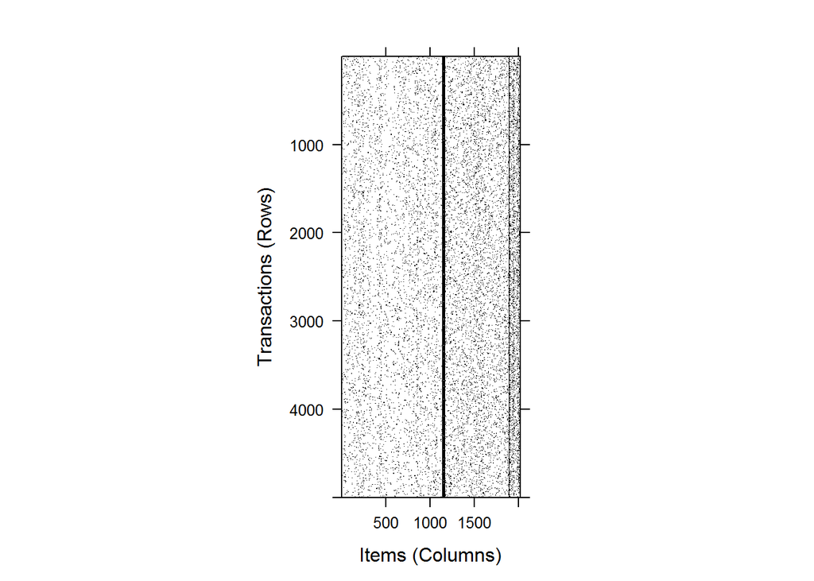

```r
image(dtrans)
```

**Interpretació del gràfic:**

Le línies amb menys espais en blanc (les més negres) són les categories que més cops s’han donat.

Hi ha massa nivells, a la imatge no podem treure conclusions perquè no es veu res clar. Així que es faran alguns canvis a la base de dades `dcat`:

1. La variable `Hotel_name` té molts nivells tot ja que es tracta d’un “identificador”, el nom dels hotels no ens és útil com a variable explicativa.
2. La variable `Review_Date`, que té tants nivells com dies diferents hagin fet la ressenya els clients, s’agruparà en anys:

Modifiquem la base de dades segons els canvis mencionats anteriorment:

```r
dcat$Review_Date_Year <- as.factor(substring(dcat$Review_Date,1,4)) # Deixem només l'any
# Eliminació de camps no necessaris
dcat$Review_Date <- NULL
dcat$Hotel_Name <- NULL
dtrans<-as(dcat, "transactions") # Transformació a transaccions
```

I ara ja podem tornar a mirar quins ítems són els més freqüents:

```r
dtrans
summary(dtrans)
dim(dtrans)
```

Els items més freqüents són els mateixos que abans:

- Is_Reviewer_Holiday=No
- Is_Hotel_Holiday=No
- Trip_Type=Leisure trip
- Room_Type_Level=Other
- Submitted_from_Mobile=Yes

Ara, a la base de dades hi ha 5000 observacions i 166 nivells. Per tant s’ha aconseguit reduir molt el nombre d’items.

Vegem-ho gràficament, amb una mostra de 100 observacions:

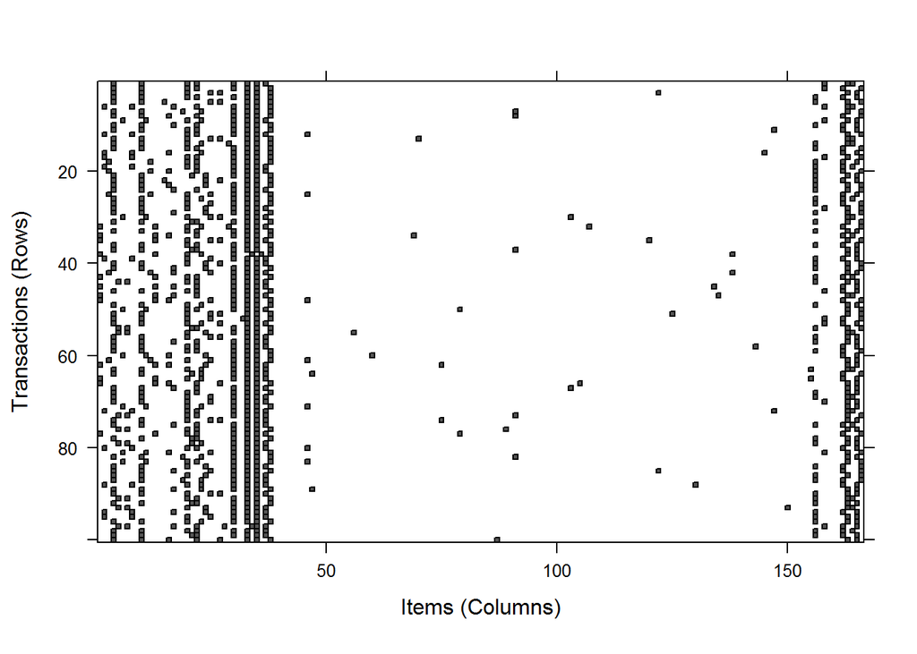

```r
image(dtrans[sample(1:length(dtrans),100)])
```

En la gràfica s’observa com els items compresos entre el nombre 50 o 150, més o menys, són poc freqüents (es veuen pocs punts negres, poques repeticions). Sabent que el nombre de nivells per categoria que tenim en aquest nova base de dades és:

|  |  | Acumulat |
| --- | --- | --- |
| Hotel_country | 6 | 6 |
| Hotel_City | 8 | 14 |
| Room_Type_Level | 7 | 21 |
| Guest_Type | 5 | 26 |
| Trip_Type | 6 | 32 |
| Is_Hotel_Holiday | 2 | 34 |
| Is_Reviewer_Holiday | 2 | 36 |
| Review_Is_Positive | 2 | 38 |
| Reviewer_Nationality | 123 | 161 |
| Submitted_from_Mobile | 2 | 163 |
| Review_date_year | 3 | 166 |
| TOTAL | 166 | - |

Podem accedir a quines són les categories més freqüents fent `levels(dcat$Factor[Nº de la categoria que es vol mirar])`.

Per exemple, veiem que les linies 4 i 10 són molt negres, mirem quines són:

```r
levels(dcat$Hotel_Country)[4]
```

```
## [1] "Gran BretaÃ±a"
```

- Per a mirar la categoria 10, veiem amb la taula de les categories acumulades que la 10 es correspon a una de les categories de la variable `Hotel_City` i, més concretament, a la `10-6=4`:

```r
levels(dcat$Hotel_City)[4]
```

```
## [1] "London"
```

Això es veu també quan fem:

```r
summary(dtrans)
```

```
## transactions as itemMatrix in sparse format with
##  5000 rows (elements/itemsets/transactions) and
##  166 columns (items) and a density of 0.06626506
##
## most frequent items:
##    Is_Reviewer_Holiday=No       Is_Hotel_Holiday=No
##                      4933                      4930
##    Trip_Type=Leisure trip     Room_Type_Level=Other
##                      4037                      3209
## Submitted_from_Mobile=Yes                   (Other)
##                      2998                     34893
##
## element (itemset/transaction) length distribution:
## sizes
##   11
## 5000
##
##    Min. 1st Qu.  Median    Mean 3rd Qu.    Max.
##      11      11      11      11      11      11
##
## includes extended item information - examples:
##                  labels     variables  levels
## 1 Hotel_Country=Austria Hotel_Country Austria
## 2 Hotel_Country=EspaÃ±a Hotel_Country EspaÃ±a
## 3 Hotel_Country=Francia Hotel_Country Francia
##
## includes extended transaction information - examples:
##   transactionID
## 1             1
## 2             2
## 3             3
```

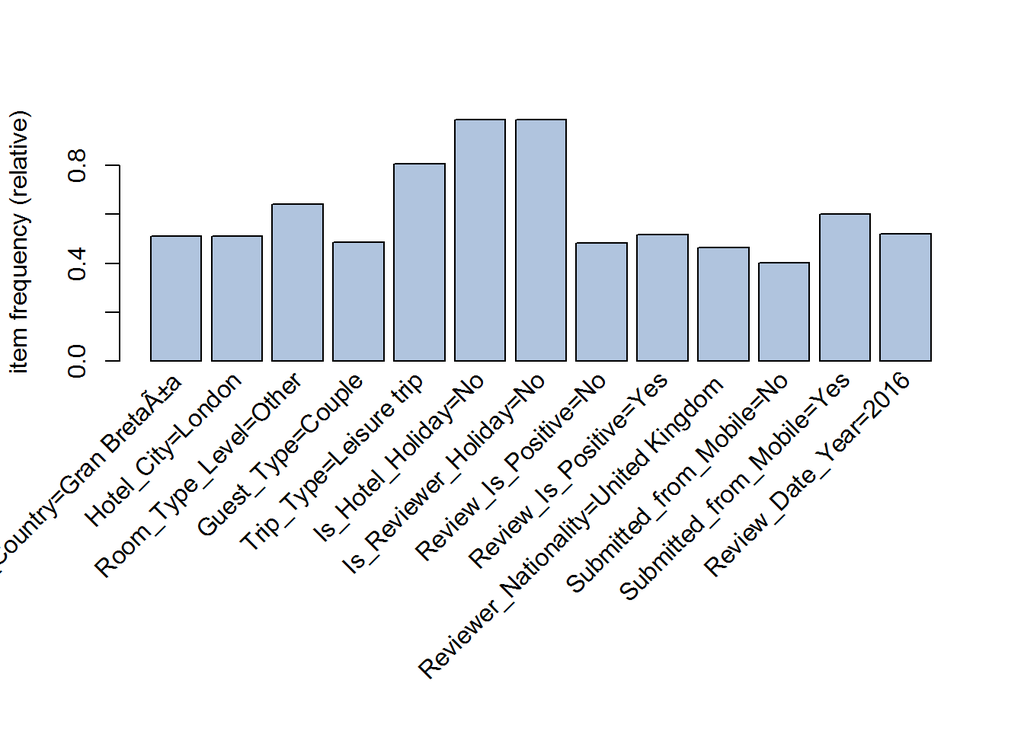

```r
itemFrequencyPlot(dtrans, support=0.3, cex.names = 1, col= 'lightsteelblue')
```

## 2.2. Algorisme Eclat

Ara, s’utilitzarà un altre algorisme per a generar itemsets freqüents, el **Eclat** (*Equivalence Class Transformation*). Es mirarà el support de cada itemset, i s’agafaran els més alts.

**Support**
$$Support(X)=\frac{Frequency \quad occurrence\quad of\quad X}{|\tau|}$$
És la fracció de transaccions que contenen l’itemset X.

```r
eclatdtrans<-eclat(dtrans, parameter = list(support=0.4, minlen=1, maxlen=5))
```

```r
inspect(head(eclatdtrans,n=14, by="support"))
```

```
##      items                       support count
## [1]  {Is_Reviewer_Holiday=No}     0.9866  4933
## [2]  {Is_Hotel_Holiday=No}        0.9860  4930
## [3]  {Is_Hotel_Holiday=No,
##       Is_Reviewer_Holiday=No}     0.9856  4928
## [4]  {Trip_Type=Leisure trip}     0.8074  4037
## [5]  {Trip_Type=Leisure trip,
##       Is_Reviewer_Holiday=No}     0.7964  3982
## [6]  {Trip_Type=Leisure trip,
##       Is_Hotel_Holiday=No}        0.7958  3979
## [7]  {Trip_Type=Leisure trip,
##       Is_Hotel_Holiday=No,
##       Is_Reviewer_Holiday=No}     0.7956  3978
## [8]  {Room_Type_Level=Other}      0.6418  3209
## [9]  {Room_Type_Level=Other,
##       Is_Reviewer_Holiday=No}     0.6340  3170
## [10] {Room_Type_Level=Other,
##       Is_Hotel_Holiday=No}        0.6336  3168
## [11] {Room_Type_Level=Other,
##       Is_Hotel_Holiday=No,
##       Is_Reviewer_Holiday=No}     0.6334  3167
## [12] {Submitted_from_Mobile=Yes}  0.5996  2998
## [13] {Is_Reviewer_Holiday=No,
##       Submitted_from_Mobile=Yes}  0.5904  2952
## [14] {Is_Hotel_Holiday=No,
##       Submitted_from_Mobile=Yes}  0.5904  2952
```

S’observen com a items molt freqüents alguns dels que s’han trobat abans:

- Is_Reviewer_Holiday=No
- Is_Hotel_Holiday=No
- Trip_Type=Leisure trip
- Room_Type_Level=Other
- Submitted_from_Mobile=Yes

Però ara, a més, trobem itemsets de dos elements:

-{Is_Hotel_Holiday=No,Is_Reviewer_Holiday=No} -{Trip_Type=Leisure trip,Is_Reviewer_Holiday=No} -{Trip_Type=Leisure trip,Is_Hotel_Holiday=No}

Ho veiem gràficament:

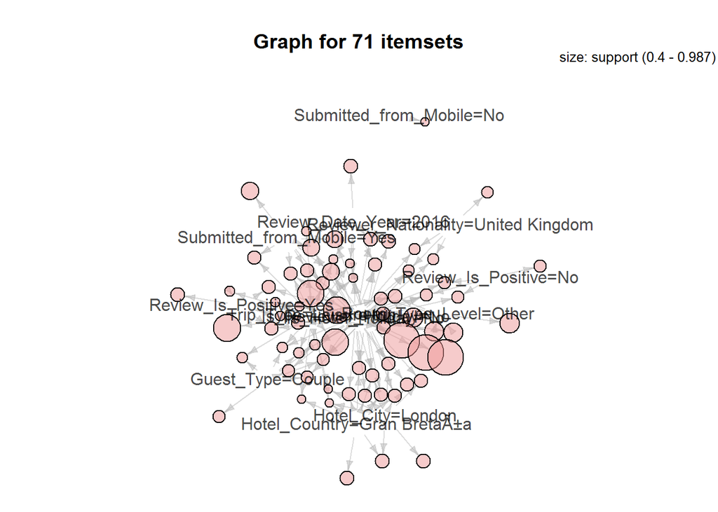

```r
library(arulesViz)
plot(eclatdtrans, method="graph")
```

Considerarem només els itemsets amb els supports més alts, els obtinguts abans:

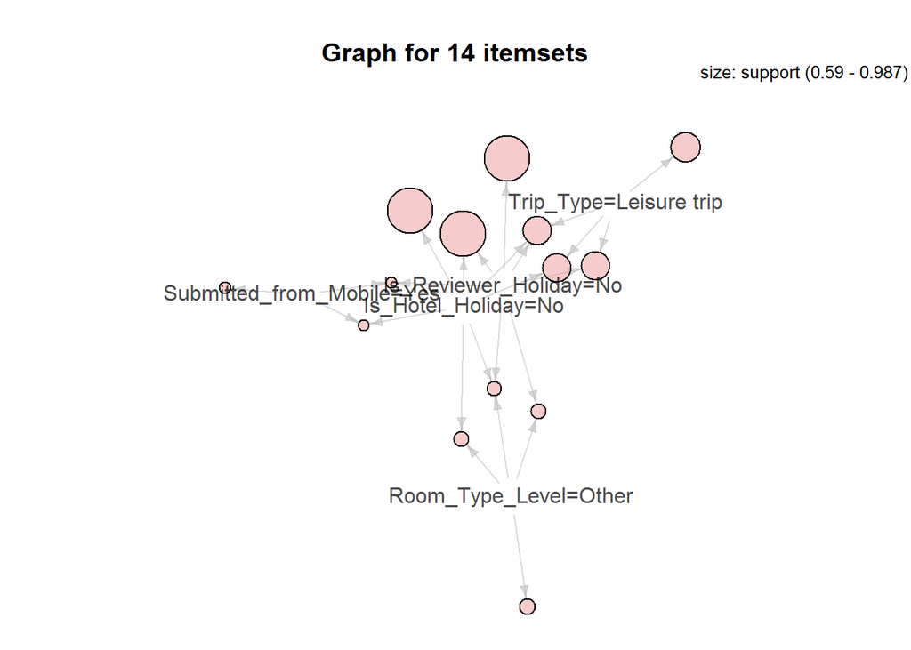

```r
plot(head(eclatdtrans,n=14, by="support"), method="graph")
```

https://rdrr.io/rforge/arulesViz/man/plot.html

# 3. Regles d’Associació.

A continuació s’utilitzarà l’algorisme Apriori (tenint en compte la confiança i el lift) per tal de trobar regles d’associació en la nostra base de dades.

**Confidence**

$$Confidence(X \rightarrow Y)= \frac{Support(X \cup Y)}{Support(X)}$$

La confiança ens indica quants cops la regla $(X \rightarrow Y)$ ha resultat ser certa. Així doncs, una confiança alta indica una alta proporció de transaccions que contenen el item X que també conté Y.

Ho apliquem a la nostra base de dades:

```r
rulesdtrans <- apriori(dtrans, parameter = list(sup = 0.02, conf = 0.05,  maxlen=5))
```

```r
inspect(head(rulesdtrans,n=15, by="confidence"))
```

```
##      lhs                                                 rhs                           support confidence      lift count
## [1]  {Hotel_City=Milan}                               => {Hotel_Country=Italia}         0.0686          1 14.577259   343
## [2]  {Hotel_Country=Italia}                           => {Hotel_City=Milan}             0.0686          1 14.577259   343
## [3]  {Reviewer_Nationality=United States of America } => {Is_Reviewer_Holiday=No}       0.0730          1  1.013582   365
## [4]  {Hotel_City=Vienna}                              => {Hotel_Country=Austria}        0.0752          1 13.297872   376
## [5]  {Hotel_Country=Austria}                          => {Hotel_City=Vienna}            0.0752          1 13.297872   376
## [6]  {Hotel_City=Amsterdam}                           => {Hotel_Country=Holanda}        0.1116          1  8.960573   558
## [7]  {Hotel_Country=Holanda}                          => {Hotel_City=Amsterdam}         0.1116          1  8.960573   558
## [8]  {Hotel_City=Barcelona}                           => {Hotel_Country=EspaÃ±a}        0.1148          1  8.710801   574
## [9]  {Hotel_Country=EspaÃ±a}                          => {Hotel_City=Barcelona}         0.1148          1  8.710801   574
## [10] {Hotel_City=Paris}                               => {Hotel_Country=Francia}        0.1178          1  8.403361   589
## [11] {Hotel_City=London}                              => {Hotel_Country=Gran BretaÃ±a}  0.5108          1  1.957713  2554
## [12] {Hotel_Country=Gran BretaÃ±a}                    => {Hotel_City=London}            0.5108          1  1.957713  2554
## [13] {Is_Hotel_Holiday=No,
##       Reviewer_Nationality=United Arab Emirates }     => {Is_Reviewer_Holiday=No}       0.0238          1  1.013582   119
## [14] {Is_Reviewer_Holiday=No,
##       Reviewer_Nationality=United Arab Emirates }     => {Is_Hotel_Holiday=No}          0.0238          1  1.014199   119
## [15] {Room_Type_Level=Family,
##       Is_Hotel_Holiday=No}                            => {Is_Reviewer_Holiday=No}       0.0254          1  1.013582   127
```

Observem que hi ha regles que són molt òbvies, aquelles en que es ja que relaciona una ciutat amb un país, ja que aquestes prediccions es poden fer molt fàcilment: si sabem la ciutat del hotel (`Hotel_City`) sempre podrem saber el país del Hotel (`Hotel_Country`).

Però, a més, es mostren altres regles interessants a comentar:

Com que la confiança per a aquestes regles és 1, això significa que sempre que una transacció conté `Reviewer_Nationality=United States of America`, la variable `Is_Reviewer_Holiday` ha estat **No**.

**Lift**

$$Lift(X \rightarrow Y)= \frac{Support(X \cup Y)}{Support(X)·Support(Y)}$$
L’elevació (*Lift*) mesura la relació entre el suport observat i esperat si els itemsets X i Y fossin independendts. Tres possibles resultats:

- **Lift = 1:** la probabilitat d’ocurrència de X i Y es independent (no hi ha regla d’associació)
- **Lift > 1:** hi ha cert grau de dependencia, per tant existeix una regla útil per a realitzar prediccions.
- **Lift < 1:** els ítems es substitueixen entre si, és a dir, quan apareix X en una transació no apareix Y i a l’inversa.

Així doncs, buscarem regles a priori ordenant-les segons el valor del lift per obtenir aquelles regles amb els lifts més alts.

```r
rulesdtrans <- apriori(dtrans, parameter = list(sup = 0.01, conf = 0.05,  maxlen=5))
```

```r
inspect(head(rulesdtrans,n=15, by="lift"))
```

```
##      lhs                           rhs                       support confidence     lift count
## [1]  {Trip_Type=Leisure trip,
##       Is_Reviewer_Holiday=Yes}  => {Is_Hotel_Holiday=Yes}     0.0108  0.9818182 70.12987    54
## [2]  {Trip_Type=Leisure trip,
##       Is_Hotel_Holiday=Yes}     => {Is_Reviewer_Holiday=Yes}  0.0108  0.9310345 69.48019    54
## [3]  {Is_Reviewer_Holiday=Yes}  => {Is_Hotel_Holiday=Yes}     0.0130  0.9701493 69.29638    65
## [4]  {Is_Hotel_Holiday=Yes}     => {Is_Reviewer_Holiday=Yes}  0.0130  0.9285714 69.29638    65
## [5]  {Hotel_Country=Italia}     => {Hotel_City=Milan}         0.0686  1.0000000 14.57726   343
## [6]  {Hotel_City=Milan}         => {Hotel_Country=Italia}     0.0686  1.0000000 14.57726   343
## [7]  {Hotel_Country=Italia,
##       Guest_Type=Group}         => {Hotel_City=Milan}         0.0110  1.0000000 14.57726    55
## [8]  {Hotel_City=Milan,
##       Guest_Type=Group}         => {Hotel_Country=Italia}     0.0110  1.0000000 14.57726    55
## [9]  {Hotel_Country=Italia,
##       Trip_Type=Business trip}  => {Hotel_City=Milan}         0.0122  1.0000000 14.57726    61
## [10] {Hotel_City=Milan,
##       Trip_Type=Business trip}  => {Hotel_Country=Italia}     0.0122  1.0000000 14.57726    61
## [11] {Hotel_Country=Italia,
##       Guest_Type=Family}        => {Hotel_City=Milan}         0.0134  1.0000000 14.57726    67
## [12] {Hotel_City=Milan,
##       Guest_Type=Family}        => {Hotel_Country=Italia}     0.0134  1.0000000 14.57726    67
## [13] {Hotel_Country=Italia,
##       Review_Date_Year=2015}    => {Hotel_City=Milan}         0.0110  1.0000000 14.57726    55
## [14] {Hotel_City=Milan,
##       Review_Date_Year=2015}    => {Hotel_Country=Italia}     0.0110  1.0000000 14.57726    55
## [15] {Hotel_Country=Italia,
##       Guest_Type=Solo traveler} => {Hotel_City=Milan}         0.0154  1.0000000 14.57726    77
```

Totes les regles obtingudes mostren una forta associació entre els itemsets de l’esquerra i els de la dreta.